# Interview the Titanic

gbida@github

2022-08-16

## Ⅰ. Summary

### Story of the Titanic

[타이타닉호 침몰의 타임라인](https://www.greelane.com/ko/인문학/역사와-문화/titanic-timeline-1779210) 참조

- 1912년 4월 15일 2,229명 중 705명 만을 남기고 침몰
- 가라앉는데 걸린 시간 2시간 40분
- 프랑스 Cherbourg항을 시작으로 아일랜드의 Queenstown항으로 가는 여정
- Mackay-Bennett, Carpathis호로 인해 생존자들 뉴욕 도착(1912.4.18)
- 타이타닉호의 잔해를 발견한 사람들ㅡDr.Robert Ballard 원정대(1985.9.1)

`때로는 결측값과 기록된 값의 차이를 만드는 것이 무엇인지 알고 싶은 경우가 있다. ㅡ R을 활용한 데이터 과학`

다양한 결측값 발생 원인들

- 설문 응답자의 실수로 답변 누락
- 민감한 질문에 대한 불응답
- 측정 장비 문제
- 연구자 측에서의 잘못으로 누락

## Ⅱ. Data Preview

### a. 자료 유형 파악하기

- 종속 변수 : Age, Cabin, Embarked, Fare
- 독립 변수 : 종속변수 데이터를 제외한 나머지 데이터들
- 연속형 변수 : PassengerId, Age, Fare
- 범주형 변수 : Survived, Pclass(순위척도), Name, Sex, Age, SibSp, Parch, Ticket, Cabin, Embarked

나이는 연속형 자료지만 10, 20대처럼 연령대로 구분하면 범주형 중에서도 *순위척도가 될 수 있다.

*순위척도 : 숫자라서 연속형 자료 같지만 평균을 내려고 하면 낼 수 없는 데이터  
예) 30대 연령 그룹이 존재하지 않는 데이터에서 20대 30명, 40대 30명이라고 해서 해당 데이터의 평균을 30대라고 할 수 없다.

```r
titanic <- read.csv('./data/titanic.csv', header = T, stringsAsFactors = T)
str(titanic)
```

```
## 'data.frame':    1309 obs. of  12 variables:
##  $ PassengerId: int  1 2 3 4 5 6 7 8 9 10 ...
##  $ Survived   : int  0 1 1 1 0 0 0 0 1 1 ...
##  $ Pclass     : int  3 1 3 1 3 3 1 3 3 2 ...
##  $ Name       : Factor w/ 1307 levels "Abbing, Mr. Anthony",..: 156 287 531 430 23 826 775 922 613 855 ...
##  $ Sex        : Factor w/ 2 levels "female","male": 2 1 1 1 2 2 2 2 1 1 ...
##  $ Age        : num  22 38 26 35 35 NA 54 2 27 14 ...
##  $ SibSp      : int  1 1 0 1 0 0 0 3 0 1 ...
##  $ Parch      : int  0 0 0 0 0 0 0 1 2 0 ...
##  $ Ticket     : Factor w/ 929 levels "110152","110413",..: 721 817 915 66 650 374 110 542 478 175 ...
##  $ Fare       : num  7.25 71.28 7.92 53.1 8.05 ...
##  $ Cabin      : Factor w/ 187 levels "","A10","A11",..: 1 108 1 72 1 1 165 1 1 1 ...
##  $ Embarked   : Factor w/ 4 levels "","C","Q","S": 4 2 4 4 4 3 4 4 4 2 ...
```

### b. 결측 데이터 처리 및 패턴 파악

Embarked 데이터 결측값(2개)과 Cabin 데이터 결측값(1014개)은 그대로 두어도 무방할 것 같아서 예측값을 채우지 않았다.

```r
summary(titanic)
```

```
##   PassengerId      Survived          Pclass
##  Min.   :   1   Min.   :0.0000   Min.   :1.000
##  1st Qu.: 328   1st Qu.:0.0000   1st Qu.:2.000
##  Median : 655   Median :0.0000   Median :3.000
##  Mean   : 655   Mean   :0.3774   Mean   :2.295
##  3rd Qu.: 982   3rd Qu.:1.0000   3rd Qu.:3.000
##  Max.   :1309   Max.   :1.0000   Max.   :3.000
##
##                                Name          Sex           Age
##  Connolly, Miss. Kate            :   2   female:466   Min.   : 0.17
##  Kelly, Mr. James                :   2   male  :843   1st Qu.:21.00
##  Abbing, Mr. Anthony             :   1                Median :28.00
##  Abbott, Master. Eugene Joseph   :   1                Mean   :29.88
##  Abbott, Mr. Rossmore Edward     :   1                3rd Qu.:39.00
##  Abbott, Mrs. Stanton (Rosa Hunt):   1                Max.   :80.00
##  (Other)                         :1301                NA's   :263
##      SibSp            Parch            Ticket          Fare
##  Min.   :0.0000   Min.   :0.000   CA. 2343:  11   Min.   :  0.000
##  1st Qu.:0.0000   1st Qu.:0.000   1601    :   8   1st Qu.:  7.896
##  Median :0.0000   Median :0.000   CA 2144 :   8   Median : 14.454
##  Mean   :0.4989   Mean   :0.385   3101295 :   7   Mean   : 33.295
##  3rd Qu.:1.0000   3rd Qu.:0.000   347077  :   7   3rd Qu.: 31.275
##  Max.   :8.0000   Max.   :9.000   347082  :   7   Max.   :512.329
##                                   (Other) :1261   NA's   :1
##              Cabin      Embarked
##                 :1014    :  2
##  C23 C25 C27    :   6   C:270
##  B57 B59 B63 B66:   5   Q:123
##  G6             :   5   S:914
##  B96 B98        :   4
##  C22 C26        :   4
##  (Other)        : 271
```

```r
which(is.na(titanic$Fare))  # 1044행
```

```
## [1] 1044
```

```r
fare_condition <- titanic[titanic$Pclass == 3 & titanic$Age >= 60 & titanic$Age < 70 & titanic$Sex == "male" & titanic$SibSp == 0 & titanic$Parch == 0,]

fare_condition <- fare_condition[complete.cases(fare_condition),]

titanic$Fare[1044] <- median(fare_condition$Fare)
titanic$Fare[1044]
```

```
## [1] 6.99375
```

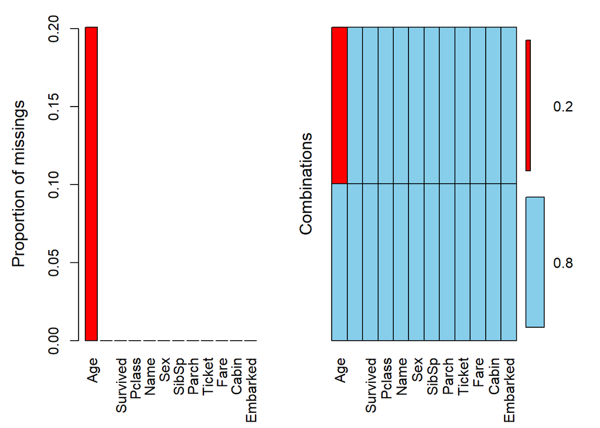

```
##
##  Variables sorted by number of missings:
##     Variable     Count
##          Age 0.2009167
##  PassengerId 0.0000000
##     Survived 0.0000000
##       Pclass 0.0000000
##         Name 0.0000000
##          Sex 0.0000000
##        SibSp 0.0000000
##        Parch 0.0000000
##       Ticket 0.0000000
##         Fare 0.0000000
##        Cabin 0.0000000
##     Embarked 0.0000000
```

```r
VIM::aggr(titanic, prop=TRUE, numbers=TRUE, sortVar=TRUE)
```

당시 탑승 선원은 855명으로 추정, 그중 객실 승무원(스튜어드)은 322명, 여성 승무원 23명으로 기록

[타이타닉 승무원](https://namu.wiki/w/RMS%20%ED%83%80%EC%9D%B4%ED%83%80%EB%8B%89) 나무위키 문서 참조

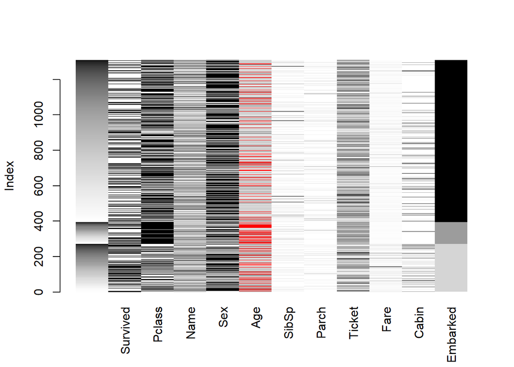

```r
VIM::matrixplot(titanic, sortby=12)
```

Age 데이터 결측값 분포는 여자 < 남자, Pclass = 3등급, 형제자매_SibSp = 0

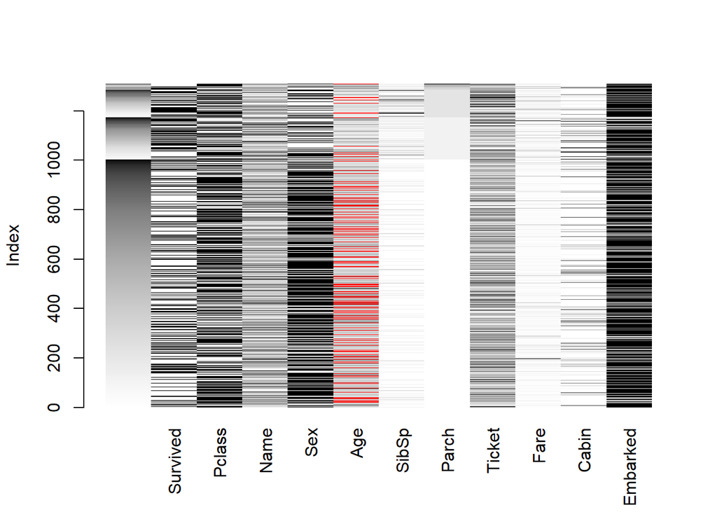

```r
VIM::matrixplot(titanic, sortby=8)
```

### c. 다중대체법 시뮬레이션?

익명을 원해서 일부러 기록을 피했다면?  
일반 사람의 범주가 아니라면?  
데이터를 꼭 채워넣어야만 할까?

```r
# library(mice)
# ini <- mice(titanic, maxit=0)
# meth <- ini$method
# meth["Age"] <- "norm.predict"
# imp <- mice(titanic, method=meth)
```

## Ⅲ. 생존에 영향을 미쳤던 변수들

Survived는 살았다, 아니다의 이분형 범주이어서 이항 로지스틱 회귀분석으로 분석 시도.  
로지스틱 회귀분석은 결측 데이터를 자동으로 삭제한다.

```r
library(modeldata)
titan.logis <- glm(Survived ~ + Sex + Embarked, data=titanic, family=binomial(link="logit"))
summary(titan.logis)
```

```
##
## Call:
## glm(formula = Survived ~ +Sex + Embarked, family = binomial(link = "logit"),
##     data = titanic)
##
## Deviance Residuals:
##     Min       1Q   Median       3Q      Max
## -2.1157  -0.4897  -0.4897   0.6564   2.1282
##
## Coefficients:
##             Estimate Std. Error z value Pr(>|z|)
## (Intercept)  13.5661   378.5929   0.036    0.971
## Sexmale      -3.4857     0.1631 -21.365   <2e-16 ***
## EmbarkedC   -11.4408   378.5929  -0.030    0.976
## EmbarkedQ   -12.2354   378.5930  -0.032    0.974
## EmbarkedS   -12.1407   378.5929  -0.032    0.974
## ---
## Signif. codes:  0 '***' 0.001 '**' 0.01 '*' 0.05 '.' 0.1 ' ' 1
##
## (Dispersion parameter for binomial family taken to be 1)
##
##     Null deviance: 1735.1  on 1308  degrees of freedom
## Residual deviance: 1064.9  on 1304  degrees of freedom
## AIC: 1074.9
##
## Number of Fisher Scoring iterations: 12
```

### b. 승객 구분에 따른 생존율 차이는 있다

생존여부와 승객 등급이라는 두 범주형 변수가 서로 관련이 있는지 교차분석(독립성검정) 해 본 결과 3등급과 승무원의 생존율이 낮았음을 알 수 있다.

```r
Titanic.margin <- margin.table(Titanic, margin=c(4, 1))
addmargins(prop.table(addmargins(Titanic.margin, 2), 2), 1)
```

```
##         Class
## Survived       1st       2nd       3rd      Crew       Sum
##      No  0.3753846 0.5859649 0.7478754 0.7604520 0.6769650
##      Yes 0.6246154 0.4140351 0.2521246 0.2395480 0.3230350
##      Sum 1.0000000 1.0000000 1.0000000 1.0000000 1.0000000
```

```r
chisq.test(Titanic.margin)
```

```
##
##  Pearson's Chi-squared test
##
## data:  Titanic.margin
## X-squared = 190.4, df = 3, p-value < 2.2e-16
```

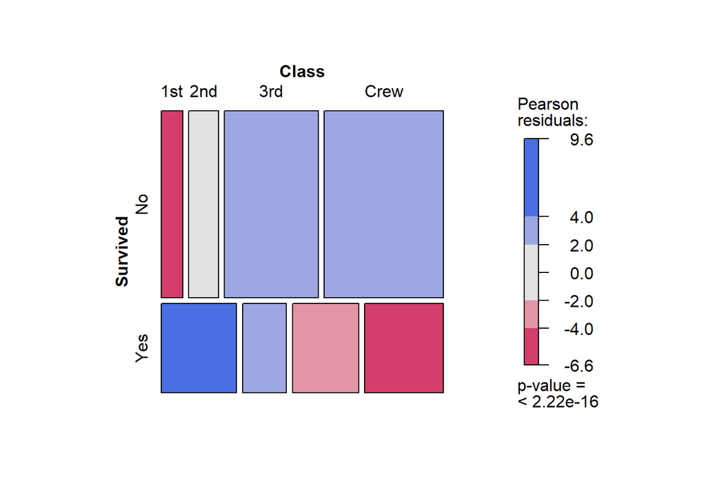

```r
library(vcd)
mosaic(Titanic.margin, shade=T, legend=T)
```

## Ⅳ. Continue

“많은 사람들이 가명으로 여행을 했고..  
2008년 광범위한 DNA 검사와 전 세계적인 족보 검색 끝에  
”알 수 없는 아이”라는 표시 아래 묻힌  
19개월 소년 시드니 레슬리 굿윈이 확인되었다.”

ㅡ [타이타닉호의 처음이자 마지막 여정의 타임라인](https://www.greelane.com/ko/인문학/역사와-문화/titanic-timeline-1779210) 중에서